# Case Study: Use the Bike-Sharing company’s historical data to find customer’s insight

Thanawat Riencharoen

2022-04-04

## Business Task

Use Cyclistic’s historical bike trip data to analyze the different behavior between annual members and causal riders and use the information to recommend the new marketing strategies to convert causal riders to annual members.

#### Key Questions

1. How do annual members and casual riders use Cyclist bikes differently?
2. Why would casual riders buy Cyclistic annual membership?
3. How can Cyclisitc use digital media to influence casual riders to become members?

## Data preparation

For this study case, I will use the R language for analysis because the data is exceed Excel row limitation (more than 5 million rows). First, I load all the data inside a new folder, installed the necessary packages, and Imported all the CSV files for every month in 2021.

```r
library(tidyverse)
library(lubridate)
```

```r
library(ggplot2)
library(dplyr)

trip_data_2022_01 <- read.csv("C:/Users/ADMIN/Desktop/Prin/Google Data Analysis/Lesson 8 Capstone Complete a Case Study/Study Case How Does a Bike-Share Navigate Speedy data/202101-divvy-tripdata.csv")
trip_data_2022_02 <- read.csv("C:/Users/ADMIN/Desktop/Prin/Google Data Analysis/Lesson 8 Capstone Complete a Case Study/Study Case How Does a Bike-Share Navigate Speedy data/202102-divvy-tripdata.csv")
trip_data_2022_03 <- read.csv("C:/Users/ADMIN/Desktop/Prin/Google Data Analysis/Lesson 8 Capstone Complete a Case Study/Study Case How Does a Bike-Share Navigate Speedy data/202103-divvy-tripdata.csv")
trip_data_2022_04 <- read.csv("C:/Users/ADMIN/Desktop/Prin/Google Data Analysis/Lesson 8 Capstone Complete a Case Study/Study Case How Does a Bike-Share Navigate Speedy data/202104-divvy-tripdata.csv")
trip_data_2022_05 <- read.csv("C:/Users/ADMIN/Desktop/Prin/Google Data Analysis/Lesson 8 Capstone Complete a Case Study/Study Case How Does a Bike-Share Navigate Speedy data/202105-divvy-tripdata.csv")
trip_data_2022_06 <- read.csv("C:/Users/ADMIN/Desktop/Prin/Google Data Analysis/Lesson 8 Capstone Complete a Case Study/Study Case How Does a Bike-Share Navigate Speedy data/202106-divvy-tripdata.csv")
trip_data_2022_07 <- read.csv("C:/Users/ADMIN/Desktop/Prin/Google Data Analysis/Lesson 8 Capstone Complete a Case Study/Study Case How Does a Bike-Share Navigate Speedy data/202107-divvy-tripdata.csv")
trip_data_2022_08 <- read.csv("C:/Users/ADMIN/Desktop/Prin/Google Data Analysis/Lesson 8 Capstone Complete a Case Study/Study Case How Does a Bike-Share Navigate Speedy data/202108-divvy-tripdata.csv")
trip_data_2022_09 <- read.csv("C:/Users/ADMIN/Desktop/Prin/Google Data Analysis/Lesson 8 Capstone Complete a Case Study/Study Case How Does a Bike-Share Navigate Speedy data/202109-divvy-tripdata.csv")
trip_data_2022_10 <- read.csv("C:/Users/ADMIN/Desktop/Prin/Google Data Analysis/Lesson 8 Capstone Complete a Case Study/Study Case How Does a Bike-Share Navigate Speedy data/202110-divvy-tripdata.csv")
trip_data_2022_11 <- read.csv("C:/Users/ADMIN/Desktop/Prin/Google Data Analysis/Lesson 8 Capstone Complete a Case Study/Study Case How Does a Bike-Share Navigate Speedy data/202111-divvy-tripdata.csv")
trip_data_2022_12 <- read.csv("C:/Users/ADMIN/Desktop/Prin/Google Data Analysis/Lesson 8 Capstone Complete a Case Study/Study Case How Does a Bike-Share Navigate Speedy data/202112-divvy-tripdata.csv")
```

Then I combine all of the loaded data into a single data frame.

```r
trip_data_2022 <- rbind(trip_data_2022_01, trip_data_2022_02, trip_data_2022_03, trip_data_2022_04, trip_data_2022_05, trip_data_2022_06, trip_data_2022_07, trip_data_2022_08, trip_data_2022_09, trip_data_2022_10, trip_data_2022_11, trip_data_2022_12)
```

## Clean data

After having a data frame to work with, I clean the data by removed any row that have missing value and rename member_causal column to member_type for clarification.

```r
trip_data_2022_clean <- na.omit(trip_data_2022)
trip_data_2022_clean <- rename(trip_data_2022_clean, member_type = member_casual)
```

## Processing data

After reviewing the cleaned data I notice that there is still lack of the information for behavior analysis, so I create new columns for biking duration, day of the week, and another column for extracted hour from the start_hours column.

```r
trip_data_process <- mutate(trip_data_2022_clean, duration = round((as.numeric(ymd_hms(ended_at) - ymd_hms(started_at)))/60))
trip_data_process <- mutate(trip_data_process, day=weekdays(ymd_hms(started_at)))
trip_data_process <- mutate(trip_data_process, started_hour=format((ymd_hms(started_at)), format = "%H"))
```

## Analyze

I start analyzing the hours first to see the difference between the time causal riders and annual members using the bike.

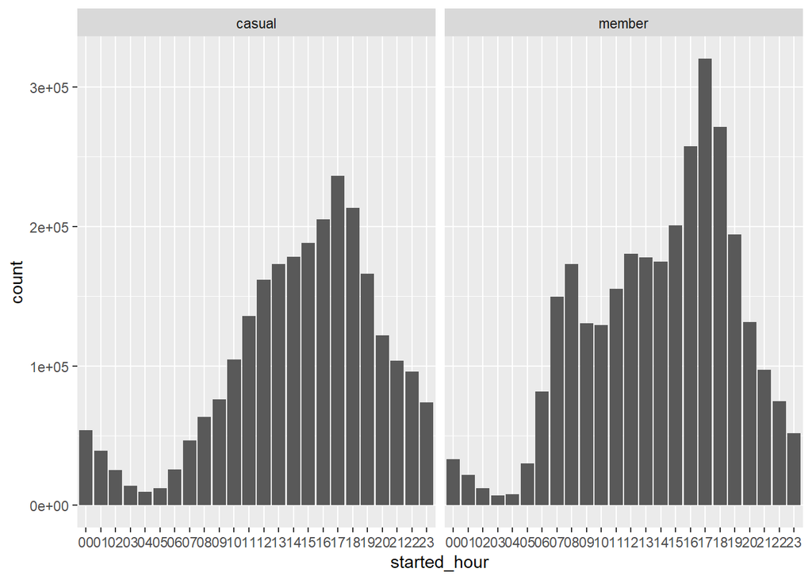

```r
ggplot(data = trip_data_process) + geom_bar(mapping = aes(x = started_hour)) + facet_wrap(~member_type)
```

I investigate further by create the bar graphs comparing the difference both groups using during the day of work.

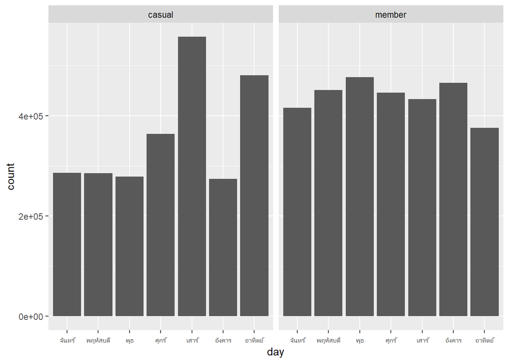

```r
ggplot(data = trip_data_process) + geom_bar(mapping = aes(x = day)) + facet_wrap(~member_type)
```

While annual members use bike usage almost the same amount everyday, casual rider’s usage is highest on Saturday and Sunday

```r
work_duration_summary <- trip_data_process %>%
  group_by(member_type) %>%
  filter(started_hour == 8 | 17) %>%
  summarise(mean(duration))
```

Now, let’s compare both groups overall riding duration and frequency to see if there is any difference in cycling behavior.

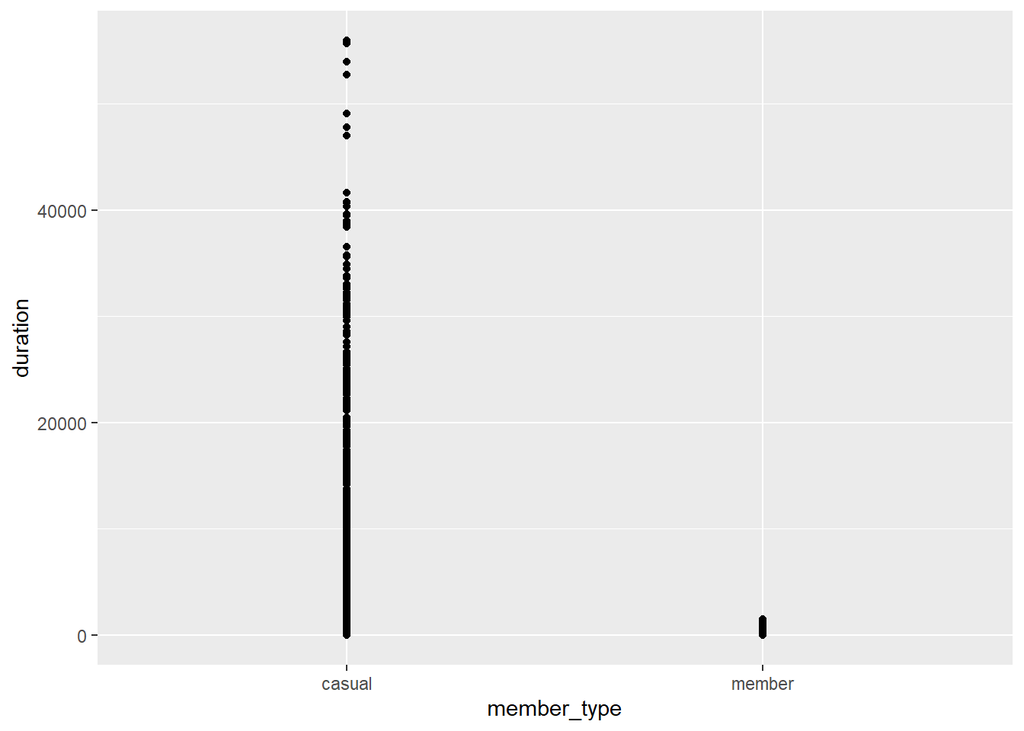

```r
work_duration_summary <- trip_data_process %>%
  group_by(member_type) %>%
  summarise(count = n() )

ggplot(data = trip_data_process) + geom_point(mapping = aes(x = member_type, y = duration))
```

The annual members cycle more but shorter duration, while causal riders cycle less often but usually cycle for longer.

Then I Create a bar graph to see which bike type is the most use for each member type.

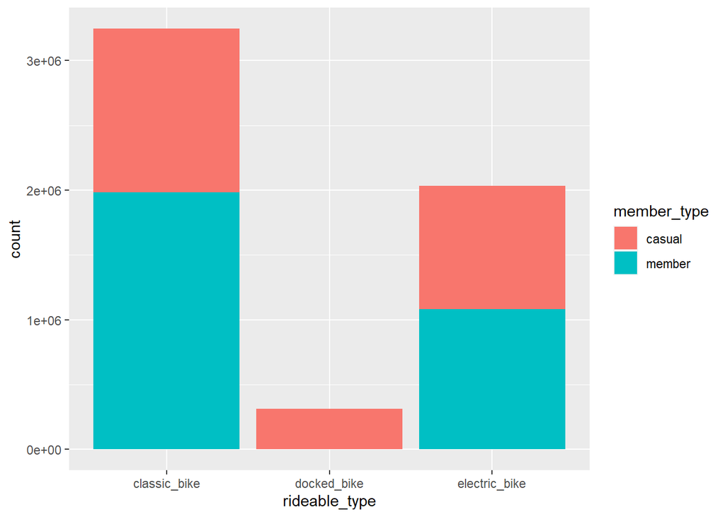

```r
ggplot(data = trip_data_process) + geom_bar(mapping = aes(x = rideable_type, fill = member_type))
```

The most popular type of bike for both groups is the classic bike, and the annual members rarely use the docked bike.

finally, I create a bar graph to see which location is the most popular cycling location for the annual members.

[figure not shown]

```r
top_location_summary <- trip_data_process %>%
  group_by(start_station_name) %>%
  filter(start_station_name != "")  %>%
  filter(member_type == "member")  %>%
  summarise(count = n()) %>%
  top_n(n = 10, wt = count) %>%
  arrange(desc(count))

  ggplot(data = top_location_summary) + geom_bar(stat='identity', mapping = aes(x =    start_station_name, y = count))
```

## Shere

#### Key insight to share and visualize

- Annual members usually use the bike to commute to work, while causal riders use the bike for much longer activities.

## Act

my recommended strategies to convert causal riders to Annual members are.

1. Promote more people around Clark St & Elm St and in the cities area to cycle to work
2. Decrease renting price on workdays to convert more causal members to cycling during the workday.
3. Promote by targeting office workers who have office syndrome to exercise more frequently.
4. Investigate further for any worries or obstructions that prevent causal riders from cycling to work.